# Q2

## Content List

- Question
- Answer
  - Libraries and Data Preparation
  - Descriptive Statistics
  - Histograms
  - Normality Test
  - Time Series Plot
  - Seasonal Plot
  - Correlations
  - Outliers
    - Z-Score
    - Isolation Forest
    - Remove Outliers
  - Regression and Variable Importance
    - First Linear Model
    - Second Linear Model
    - Random Forest Model

## Question

[figure not shown]

This Analysis is made by : Billy

### Libraries and Data Preparation

```python
# Libraries
import pandas as pd
import numpy as np
import seaborn as sns
from matplotlib import pyplot as plt
from math import sqrt
import statsmodels.api as sm
from scipy import stats
from sklearn.ensemble import IsolationForest
from sklearn.ensemble import RandomForestRegressor
from sklearn.metrics import mean_squared_error
from answerQ2 import *
```

```python
# Load Data
data = pd.read_csv('./palm_ffb.csv')
```

```python
data.head(n=5)
```

|  | Date | SoilMoisture | Average_Temp | Min_Temp | Max_Temp | Precipitation | Working_days | HA_Harvested | FFB_Yield |
| --- | --- | --- | --- | --- | --- | --- | --- | --- | --- |
| 0 | 01.01.2008 | 616.4 | 25.306452 | 21.3 | 32.2 | 184.4 | 25 | 777778.3951 | 1.62 |
| 1 | 01.02.2008 | 568.9 | 26.165517 | 20.9 | 35.1 | 140.2 | 23 | 767988.2759 | 1.45 |
| 2 | 01.03.2008 | 577.6 | 25.448387 | 21.3 | 32.9 | 280.4 | 25 | 783951.9231 | 1.56 |
| 3 | 01.04.2008 | 581.1 | 26.903333 | 20.6 | 34.8 | 173.3 | 25 | 788987.0504 | 1.39 |
| 4 | 01.05.2008 | 545.4 | 27.241935 | 20.9 | 35.0 | 140.6 | 25 | 813659.7222 | 1.44 |

```python
# Change "Date" Column Data Type from String to Date
data['Date'] = pd.to_datetime(data['Date'].astype(str), format='%d.%m.%Y')
```

```python
# Data Structure
data.info()
```

```
<class 'pandas.core.frame.DataFrame'>
RangeIndex: 130 entries, 0 to 129
Data columns (total 9 columns):
 #   Column         Non-Null Count  Dtype
---  ------         --------------  -----
 0   Date           130 non-null    datetime64[ns]
 1   SoilMoisture   130 non-null    float64
 2   Average_Temp   130 non-null    float64
 3   Min_Temp       130 non-null    float64
 4   Max_Temp       130 non-null    float64
 5   Precipitation  130 non-null    float64
 6   Working_days   130 non-null    int64
 7   HA_Harvested   130 non-null    float64
 8   FFB_Yield      130 non-null    float64
dtypes: datetime64[ns](1), float64(7), int64(1)
memory usage: 9.3 KB
```

- Number of Rows (Observations) : 130
- Number of Columns (Variables) : 9

```python
# Check For Null Values
data.isnull().values.any()
```

```
False
```

No Null Value

### Descriptive Statistics

```python
data.describe()
```

|  | SoilMoisture | Average_Temp | Min_Temp | Max_Temp | Precipitation | Working_days | HA_Harvested | FFB_Yield |
| --- | --- | --- | --- | --- | --- | --- | --- | --- |
| count | 130.000000 | 130.000000 | 130.000000 | 130.000000 | 130.000000 | 130.000000 | 130.000000 | 130.000000 |
| mean | 527.646923 | 26.849918 | 21.379231 | 33.851538 | 188.980769 | 24.753846 | 793404.491565 | 1.602231 |
| std | 57.367844 | 0.651413 | 0.688971 | 1.079638 | 80.237210 | 1.239289 | 34440.893854 | 0.281751 |
| min | 380.700000 | 25.158065 | 18.900000 | 31.100000 | 2.000000 | 21.000000 | 683431.944400 | 1.080000 |
| 25% | 488.625000 | 26.442285 | 21.000000 | 33.100000 | 140.300000 | 24.000000 | 768966.949100 | 1.390000 |
| 50% | 538.300000 | 26.930645 | 21.500000 | 33.900000 | 182.150000 | 25.000000 | 790036.158050 | 1.585000 |
| 75% | 571.025000 | 27.270726 | 21.800000 | 34.600000 | 226.100000 | 26.000000 | 821989.235250 | 1.807500 |
| max | 647.300000 | 28.580000 | 22.600000 | 36.000000 | 496.100000 | 27.000000 | 882254.225400 | 2.270000 |

### Histograms

```python
# Data without "Date" Column
data_dropDate = data.copy()
data_dropDate = data_dropDate.drop('Date', axis=1)
```

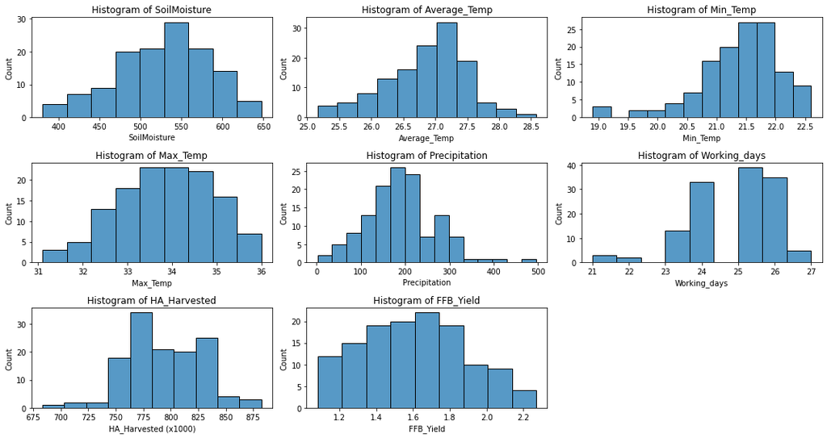

```python
show_histograms(data_dropDate)
```

### Normality Test

```python
result = show_normality_test(data_dropDate)
result
```

|  | variable | shapiro_wilk_test_p_value | shapiro_wilk_test_p_result | d_agostinos_k_squared_test_p_value | d_agostinos_k_squared_test_result |
| --- | --- | --- | --- | --- | --- |
| 0 | SoilMoisture | 8.354291e-02 | H0 : Gaussian | 1.540482e-01 | H0 : Gaussian |
| 1 | Average_Temp | 1.365993e-01 | H0 : Gaussian | 2.411032e-01 | H0 : Gaussian |
| 2 | Min_Temp | 6.362262e-06 | Ha : Not Gaussian | 3.936961e-07 | Ha : Not Gaussian |
| 3 | Max_Temp | 2.031572e-01 | H0 : Gaussian | 1.118977e-01 | H0 : Gaussian |
| 4 | Precipitation | 3.651341e-02 | Ha : Not Gaussian | 4.819146e-03 | Ha : Not Gaussian |
| 5 | Working_days | 3.607250e-07 | Ha : Not Gaussian | 5.290826e-03 | Ha : Not Gaussian |
| 6 | HA_Harvested | 1.924810e-01 | H0 : Gaussian | 8.868041e-01 | H0 : Gaussian |
| 7 | FFB_Yield | 9.630228e-02 | H0 : Gaussian | 5.738294e-02 | H0 : Gaussian |

Findings :

- Min Temp, Precipitation, and Working Days : Non-Parametric (Not Normal Distribution)
- The Rest : Normal Distribution (Parametric)

### Time Series Plot

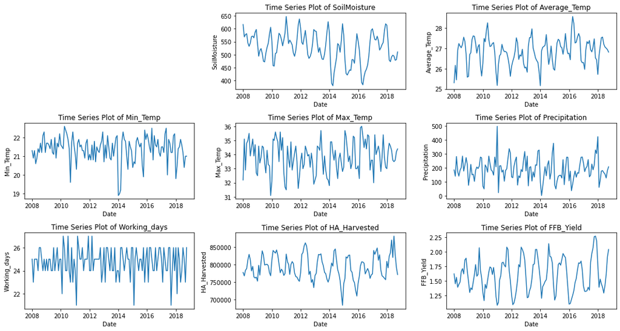

```python
show_time_series_plot(data)
```

As we can see from Time Series Plot, Osicaltion occurs which indicates Seasonal Pattern.

### Seasonal Plot

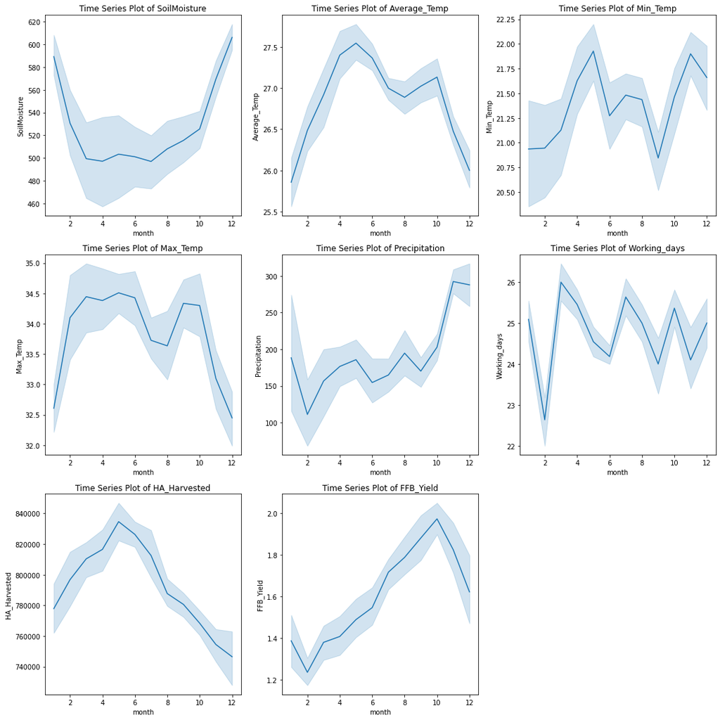

```python
show_seasonal_plot(data)
```

As I suspected, there is seasonal pattern here !

- Harvesting activity increased in first semester and then decrese in second semester
- FFB yields increased in the second half as rainfall (precipitation) increased
- Precipitation seems affect both soil moisture (Positive Correlation) and average temperature (Negative Correlation)
- Working days are fluctuates around 25 days

### Correlations

[figure not shown]

```python
# Correlation Matrix
result = show_correlation_matrix(data_dropDate)
result
```

|  | SoilMoisture | Average_Temp | Min_Temp | Max_Temp | Precipitation | Working_days | HA_Harvested | FFB_Yield |
| --- | --- | --- | --- | --- | --- | --- | --- | --- |
| SoilMoisture | 1.000000 | -0.649878 | 0.015839 | -0.499936 | 0.552001 | -0.057015 | -0.326539 | -0.003183 |
| Average_Temp | -0.649878 | 1.000000 | 0.180396 | 0.761083 | -0.369386 | 0.076321 | 0.446515 | -0.005494 |
| Min_Temp | 0.015839 | 0.180396 | 1.000000 | -0.124754 | 0.345944 | 0.068414 | 0.024396 | 0.103830 |
| Max_Temp | -0.499936 | 0.761083 | -0.124754 | 1.000000 | -0.461117 | -0.039112 | 0.314827 | -0.071201 |
| Precipitation | 0.552001 | -0.369386 | 0.345944 | -0.461117 | 1.000000 | 0.127897 | -0.265866 | 0.289604 |
| Working_days | -0.057015 | 0.076321 | 0.068414 | -0.039112 | 0.127897 | 1.000000 | 0.048876 | 0.116364 |
| HA_Harvested | -0.326539 | 0.446515 | 0.024396 | 0.314827 | -0.265866 | 0.048876 | 1.000000 | -0.350222 |
| FFB_Yield | -0.003183 | -0.005494 | 0.103830 | -0.071201 | 0.289604 | 0.116364 | -0.350222 | 1.000000 |

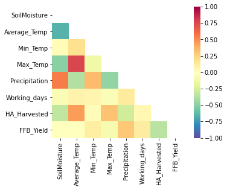

```python
show_correlation_matrix_heat_map(data_dropDate)
```

```python
print("Top 5 Positive Correlations")
print(get_top_pos_correlations(data_dropDate, 5))
```

```
Top 5 Positive Correlations
Average_Temp  Max_Temp         0.761083
SoilMoisture  Precipitation    0.552001
Average_Temp  HA_Harvested     0.446515
Min_Temp      Precipitation    0.345944
Max_Temp      HA_Harvested     0.314827
dtype: float64
```

- Average Temp & Max Temp : High Positive Correlation (Obvious, Max Temp affects Average Temp)
- Soil Moisture & Precipitation : Moderate Positive Correlation (Obvious, more precipitation leads to more water content in soil)
- The Rest : Low Positive Correlation

```python
print("Top 5 Negative Correlations")
print(get_top_neg_correlations(data_dropDate, 5))
```

```
Top 5 Negative Correlations
SoilMoisture  Average_Temp    -0.649878
              Max_Temp        -0.499936
Max_Temp      Precipitation   -0.461117
Average_Temp  Precipitation   -0.369386
HA_Harvested  FFB_Yield       -0.350222
dtype: float64
```

- Soil Moisture & Average Temp : Moderate Negative Correlation (Obvious, Higher Temperature will increase evaporation, hence reducing water content on soil)
- Soil Moisture & Max Temp : Low Negative Correlation (Obvious, same as Average Temp)
- Max Temp & Precipitation : Low Negative Correlation (Obvious, Precipitation will reduce environment temperature)
- Average Temp & Precipitation : Low Negative Correlation (Obvious, same as Max Temp)
- FFB Yield & HA Harvested : Low Negative Correlation (Obvious, harvesting is a process of collecting FFB, hence reducing FFB yield)

```python
print("Target Variable (FFB_Yield) Correlation with Others")
get_target_correlations(data_dropDate,"FFB_Yield")
```

```
Target Variable (FFB_Yield) Correlation with Others
```

|  | Target | Features | Correlation Value |
| --- | --- | --- | --- |
| 60 | FFB_Yield | Precipitation | 0.289604 |
| 61 | FFB_Yield | Working_days | 0.116364 |
| 58 | FFB_Yield | Min_Temp | 0.103830 |
| 56 | FFB_Yield | SoilMoisture | -0.003183 |
| 57 | FFB_Yield | Average_Temp | -0.005494 |
| 59 | FFB_Yield | Max_Temp | -0.071201 |
| 62 | FFB_Yield | HA_Harvested | -0.350222 |

- FFB Yield & Precipitation : Low Positive Correlation (more precipitation leads to more yield)
- FFB Yield & Working Days : Very Low Positive Correlation (more work leads to more yield)
- FFB Yield & HA Harvested : Low Negative Correlation (Obvious, harvesting is a process of collecting FFB, hence reducing FFB yield)
- The Rest : Very Low Correlation

### Outliers

#### Z-Score

```python
# Detect Outliers from Z-Score (Z > 3 considered as outliers)
data_dropDate[(np.abs(stats.zscore(data_dropDate)) > 3).all(axis=1)]
```

|  | SoilMoisture | Average_Temp | Min_Temp | Max_Temp | Precipitation | Working_days | HA_Harvested | FFB_Yield |
| --- | --- | --- | --- | --- | --- | --- | --- | --- |

No Outliers found with this method

#### Isolation Forest

```python
model_isoF =  IsolationForest(n_estimators=50, max_samples=500, contamination=.01, max_features=len(data_dropDate.columns.to_list()),
                         bootstrap=False, n_jobs=1, random_state=1, verbose=0, warm_start=False).fit(data_dropDate)
```

```python
outliers_flag = model_isoF.predict(data_dropDate)
data_outliers = data.copy()
data_outliers['outliers_flag'] = outliers_flag
data_outliers['outliers_flag'] = np.where((data_outliers['outliers_flag'] == -1), "True", "False")
data_outliers = data_outliers[data_outliers["outliers_flag"] == "True"]

data_outliers
```

|  | Date | SoilMoisture | Average_Temp | Min_Temp | Max_Temp | Precipitation | Working_days | HA_Harvested | FFB_Yield | month | outliers_flag |
| --- | --- | --- | --- | --- | --- | --- | --- | --- | --- | --- | --- |
| 36 | 2011-01-01 | 647.3 | 25.170968 | 21.1 | 31.5 | 496.1 | 24 | 830578.7037 | 1.08 | 1 | True |
| 72 | 2014-01-01 | 584.9 | 25.158065 | 18.9 | 31.8 | 96.7 | 24 | 761886.0927 | 1.51 | 1 | True |

There are two outliers !

#### Remove Outliers

```python
data_outliers_dates = data_outliers["Date"].to_list()
data_no_outliers = data.copy()
data_no_outliers = data_no_outliers[~data_no_outliers["Date"].isin(data_outliers_dates)]
```

### Regression and Variable Importance

In this case, regression is used to find significant variable.

```python
# Set Target/Response/Dependent Variable as "FFB_Yield"
y_train = data_no_outliers["FFB_Yield"].copy()
y_test = data["FFB_Yield"].copy()
```

#### First Linear Model

Try a Simple Model First :)

```python
# Select some Features for Linear Model

# Drop "Date" and "month" Columns and also "FFB_Yield"
# Don't forget to drop "Max_Temp" that have high correlation value with "Average_Temp"

x_train1 = data_no_outliers.copy()
x_train1 = x_train1.drop(["Date","month","FFB_Yield","Max_Temp"], axis=1)

x_test1 = data.copy()
x_test1 = x_test1.drop(["Date","month","FFB_Yield","Max_Temp"], axis=1)

# adding a constant
x_train1 = sm.add_constant(x_train1)
x_test1 = sm.add_constant(x_test1)
```

```python
# Create First Linear Model
model_lin1 = sm.OLS(y_train, x_train1).fit()
print(model_lin1.summary())
```

```
                            OLS Regression Results
==============================================================================
Dep. Variable:              FFB_Yield   R-squared:                       0.272
Model:                            OLS   Adj. R-squared:                  0.235
Method:                 Least Squares   F-statistic:                     7.519
Date:                Wed, 27 Oct 2021   Prob (F-statistic):           7.31e-07
Time:                        15:11:27   Log-Likelihood:                 2.1003
No. Observations:                 128   AIC:                             9.799
Df Residuals:                     121   BIC:                             29.76
Df Model:                           6
Covariance Type:            nonrobust
=================================================================================
                    coef    std err          t      P>|t|      [0.025      0.975]
---------------------------------------------------------------------------------
const             3.2117      1.551      2.071      0.040       0.142       6.282
SoilMoisture     -0.0013      0.001     -2.307      0.023      -0.002      -0.000
Average_Temp      0.0520      0.049      1.052      0.295      -0.046       0.150
Min_Temp         -0.0322      0.037     -0.869      0.386      -0.106       0.041
Precipitation     0.0017      0.000      4.373      0.000       0.001       0.002
Working_days      0.0093      0.018      0.518      0.605      -0.026       0.045
HA_Harvested  -2.757e-06   7.35e-07     -3.751      0.000   -4.21e-06    -1.3e-06
==============================================================================
Omnibus:                        1.248   Durbin-Watson:                   0.641
Prob(Omnibus):                  0.536   Jarque-Bera (JB):                1.130
Skew:                          -0.050   Prob(JB):                        0.568
Kurtosis:                       2.551   Cond. No.                     5.69e+07
==============================================================================

Notes:
[1] Standard Errors assume that the covariance matrix of the errors is correctly specified.
[2] The condition number is large, 5.69e+07. This might indicate that there are
strong multicollinearity or other numerical problems.
```

From model summary above : "SoilMoisture", "Precipitation", and "HA_Harvested" have p-value less than 0.05.  
These three variables are significant to predict FFB Yield. Notice that "Precipitation" and "HA_Harvested" are more significant than "SoilMoisture"

```python
# Prediction
pred_model_lin1 = model_lin1.predict(x_test1)
```

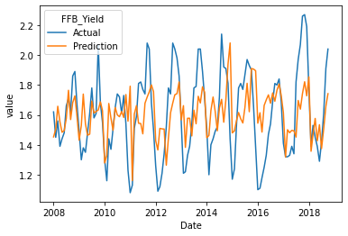

```python
# Plot Model Prediction for "FFB Yield"
show_time_series_prediction_plot(data,model_lin1,x_test1)
```

Hm... Not bad. Let's check the RMSE (One of metrics to evaluate Regression)

```python
# RMSE for First Linear Model
rmse_model_lin1 = sqrt(mean_squared_error(y_test,pred_model_lin1))
rmse_model_lin1
```

```
0.24436586098890978
```

#### Second Linear Model

Simple Model with Significant Variables

```python
# Pick only significant variables
x_train2 = data_no_outliers.copy()
x_train2 = x_train2[["SoilMoisture", "Precipitation","HA_Harvested"]]

x_test2 = data.copy()
x_test2 = x_test2[["SoilMoisture", "Precipitation","HA_Harvested"]]

# adding a constant
x_train2 = sm.add_constant(x_train2)
x_test2 = sm.add_constant(x_test2)
```

```python
# Create Second Linear Model
model_lin2 = sm.OLS(y_train, x_train2).fit()
print(model_lin2.summary())
```

```
                            OLS Regression Results
==============================================================================
Dep. Variable:              FFB_Yield   R-squared:                       0.260
Model:                            OLS   Adj. R-squared:                  0.242
Method:                 Least Squares   F-statistic:                     14.53
Date:                Wed, 27 Oct 2021   Prob (F-statistic):           3.59e-08
Time:                        15:11:28   Log-Likelihood:                 1.1043
No. Observations:                 128   AIC:                             5.791
Df Residuals:                     124   BIC:                             17.20
Df Model:                           3
Covariance Type:            nonrobust
=================================================================================
                    coef    std err          t      P>|t|      [0.025      0.975]
---------------------------------------------------------------------------------
const             4.1174      0.640      6.434      0.000       2.851       5.384
SoilMoisture     -0.0016      0.000     -3.359      0.001      -0.002      -0.001
Precipitation     0.0016      0.000      4.713      0.000       0.001       0.002
HA_Harvested  -2.511e-06   6.81e-07     -3.690      0.000   -3.86e-06   -1.16e-06
==============================================================================
Omnibus:                        1.053   Durbin-Watson:                   0.641
Prob(Omnibus):                  0.591   Jarque-Bera (JB):                1.006
Skew:                          -0.035   Prob(JB):                        0.605
Kurtosis:                       2.571   Cond. No.                     2.36e+07
==============================================================================

Notes:
[1] Standard Errors assume that the covariance matrix of the errors is correctly specified.
[2] The condition number is large, 2.36e+07. This might indicate that there are
strong multicollinearity or other numerical problems.
```

Ok! We create a linear model with all significant variables. Again, can the prediction fits with actual data ?

```python
# Prediction
pred_model_lin2 = model_lin2.predict(x_test2)
```

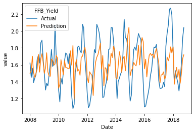

```python
# Plot Model Prediction for "FFB Yield" (Second Linear Model)
show_time_series_prediction_plot(data,model_lin2,x_test2)
```

```python
# RMSE for Second Linear Model
rmse_model_lin2 = sqrt(mean_squared_error(y_test,pred_model_lin2))
rmse_model_lin2
```

```
0.24697820546036447
```

Hm.. need improvement here ...

#### Random Forest Model

Random Forest is a Non-Parametric Model and suitable for non-linear data

```python
# Pick only significant variables
x_train3 = data_no_outliers.copy()
x_train3 = x_train3[["SoilMoisture", "Precipitation","HA_Harvested"]]

x_test3 = data.copy()
x_test3 = x_test3[["SoilMoisture", "Precipitation","HA_Harvested"]]
```

```python
# Create Random Forest Model
model_rf = RandomForestRegressor(n_estimators=50, criterion='mse', max_depth=3)
model_rf.fit(x_train3, y_train)
```

```
RandomForestRegressor(max_depth=3, n_estimators=50)
```

```python
# Prediction
pred_model_rf = model_rf.predict(x_test3)
```

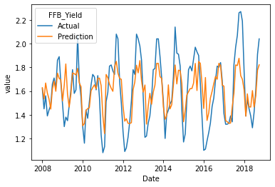

```python
# Plot Model Prediction for "FFB Yield" (Second Linear Model)
show_time_series_prediction_plot(data,model_rf,x_test3)
```

```python
# RMSE for Second Linear Model
rmse_model_rf = sqrt(mean_squared_error(y_test,pred_model_rf))
rmse_model_rf
```

```
0.19045135922461373
```

Ok! Much better than previous linear model :)

```python
# Feature Importance
show_model_rf_feature_importance(model_rf,x_train3)
```

|  | feature_name | importance_score |
| --- | --- | --- |
| 2 | HA_Harvested | 0.444263 |
| 1 | Precipitation | 0.360344 |
| 0 | SoilMoisture | 0.195393 |

We can see the order of significant variables here.  
First is "HA_Harvested", followed by "Precipitation", and the last is "SoilMoisture"

**Additional Notes**  
We have identified three significant variables ("HA_Harvested", "Precipitation", "SoilMoisture").  
Keep in mind that regression is used to find those variables.  
The main purpose is to find those variables, not to predict "FFB Yield" accurately/robustly.  
Reproducing a robust model will required Cross-Validation technique.